# Simulation results: equalblocks.01

Published

October 29, 2026

# Scenario

High dimensional scenario intended for p = 1000 (npredictors is NOT a signature key; it is passed on the run_sim.sh command line). Three blocks of equal size (indep / weak / strong), 30 designed actives spread evenly across them (10 per block). |beta1| ~ Uniform(0.25, 0.75) with a random sign, so each active effect is in [0.25, 0.75] or [-0.75, -0.25]. Magnitudes were softened from an earlier draft (50 actives, U(0.5, 1.5)) whose linear predictor had sd ~5.9, which made event type nearly deterministic for half the sample. beta2 = -beta1 via the “neg_beta1” sentinel.

```r
kbl(scenario_overview(res))
```

Table 1: Data generating settings

| Setting | Value |
| --- | --- |
| Scenario | equalblocks.01 |
| Predictors (p) | 1000 |
| Observations (n) | 500 |
| Completed runs | 50 |
| Active predictors (cause 1) | 30 (11 positive, 19 negative) |
| Cause 1 effects | \|beta1\| in [0.29, 0.72] |
| Cause 2 effects | beta2 = -beta1 |
| Censoring | Exponential, rate 0.05 |
| Observation window (u) | [50, 150] |
| Latent type | gaussian |
| Zero gap target (autotune beta_min) | 0.1 |
| C-index horizon (eval_time) | 100 |

```r
kbl(block_design_table(res), digits = 2)
```

Table 2: Correlation blocks. Predictors are split into blocks with a common within-block correlation; the active predictors are spread across the blocks.

| Block | Within-block rho | Latent q | Proportion | Predictors | Active | Active \|beta1\| range |
| --- | --- | --- | --- | --- | --- | --- |
| indep | 0.0 | 0.5 | 0.34 | 340 | 10 | 0.29 to 0.72 |
| weak | 0.3 | 0.4 | 0.33 | 330 | 10 | 0.30 to 0.70 |
| strong | 0.7 | 0.5 | 0.33 | 330 | 10 | 0.29 to 0.70 |

## Simulation run

```r
prov <- run_provenance(res, root)
kbl(prov$summary)
```

Table 3: Provenance of the parsed results

| Item | Value |
| --- | --- |
| Scenario manifest created | 2026-10-27T18:38:20 |
| Manifest git commit | 546fb3b |
| Parsed tables last written | 2026-10-29 15:38 |
| Run numbers | 1 to 50 (50 runs) |

```r
if (is.null(prov$commits)) {
  cat("Git history not available here.")
} else {
  kbl(prov$commits)
}
```

Table 4: Commits that touched this scenario’s parsed results

| Commit | Date | Message |
| --- | --- | --- |
| 8d750e6 | 2026-10-29 15:38 | equal blocks.01 at p=1000 for 50 |

## Models compared

```r
kbl(models[, c("label", "model", "role")],
    col.names = c("Label", "Id in results", "Role"))
```

Table 5

| Label | Id in results | Role |
| --- | --- | --- |
| bhCRR | bhcrr | proposed |
| Oracle FG | fg_oracle | oracle |
| LASSO | lasso | comparator |
| aLASSO | alasso | comparator |
| SCAD | scad | comparator |
| MCP | mcp | comparator |

## Run health

```r
health <- run_health(res, models)
kbl(health)
```

Table 6: Runs per model. Usable = converged and returned coefficients; only usable runs enter the bias and selection summaries. Fit time includes shared comparator setup.

| Model | Runs | Converged | Usable | Median selected | Median fit (min) |
| --- | --- | --- | --- | --- | --- |
| bhCRR | 50 | 50 | 50 | 21.0 | 43.97 |
| Oracle FG | 50 | 50 | 50 | 30.0 | 0.00 |
| LASSO | 50 | 50 | 50 | 25.0 | 7.03 |
| aLASSO | 50 | 0 | 0 | NA | 12.78 |
| SCAD | 50 | 50 | 50 | 124.5 | 0.57 |
| MCP | 50 | 50 | 50 | 107.5 | 0.63 |

```r
bad <- health[health$Usable < health$Runs, ]
if (nrow(bad)) {
  cat("::: {.callout-warning}\n## Failed fits\n\n")
  cat(sprintf("- **%s**: %d of %d runs usable.%s\n", bad$Model, bad$Usable,
              bad$Runs, ifelse(bad$Usable == 0,
                               " It is absent from every plot and table below.",
                               "")), sep = "")
  cat(":::\n")
}
```

**WarningFailed fits**

- **aLASSO**: 0 of 50 runs usable. It is absent from every plot and table below.

```r
tune <- tuning_summary(res, models)
if (!is.null(tune)) kbl(tune)
```

Table 7: Tuning diagnostics for models that report them

| Model | s0 median (range) | s1 median (range) | Autotune attempts | Grid checks passed | EM iterations median (range) |
| --- | --- | --- | --- | --- | --- |
| bhCRR | 0.01793 (0.006294 to 0.01913) | 0.2 (0.2 to 0.6) | 1: 4, 2: 46 | 0 / 50 | 7.5 (5 to 61) |

# Coefficient bias

The bias summaries cover the 30 active predictors only. Panels are the correlation blocks, ordered by within-block correlation.

```r
bias_sum <- summarise_bias(res$betas, models, active_only = TRUE)
```

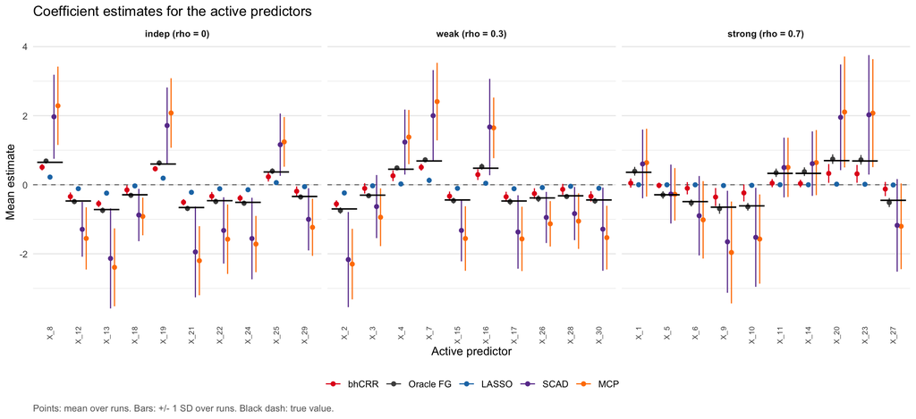

Figure 1: Mean estimate by predictor against the true coefficient.

```r
plot_estimates(bias_sum)
```

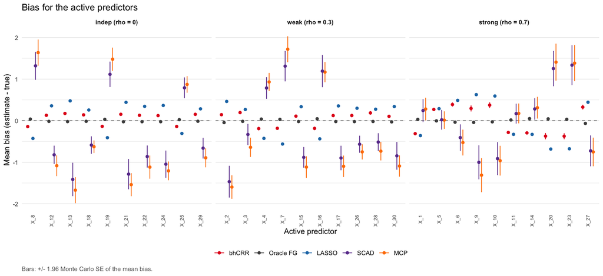

Figure 2: Mean bias by predictor.

```r
plot_bias(bias_sum)
```

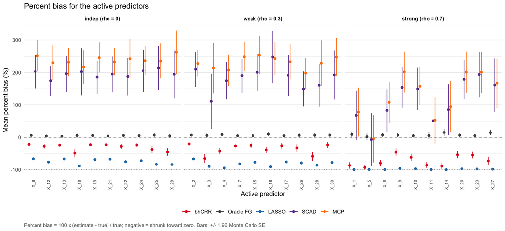

Figure 3: Mean percent bias by predictor. Negative values are shrinkage toward zero for either sign of the truth; the dotted line at -100% is an estimate of exactly zero.

```r
plot_pct_bias(bias_sum)
```

```r
kbl(bias_by_block(res$betas, models), digits = 3)
```

Table 8: Bias over the active predictors, by block

| Model | Block | Mean % bias | Mean \|bias\| | RMSE | % estimated as 0 |
| --- | --- | --- | --- | --- | --- |
| bhCRR | indep (rho = 0) | -30.233 | 0.149 | 0.181 | 9.4 |
| Oracle FG | indep (rho = 0) | 4.807 | 0.063 | 0.079 | 0.0 |
| LASSO | indep (rho = 0) | -74.514 | 0.367 | 0.379 | 11.2 |
| SCAD | indep (rho = 0) | 195.826 | 1.042 | 1.483 | 1.6 |
| MCP | indep (rho = 0) | 238.888 | 1.222 | 1.557 | 1.0 |
| bhCRR | weak (rho = 0.3) | -35.872 | 0.169 | 0.212 | 20.6 |
| Oracle FG | weak (rho = 0.3) | 6.248 | 0.068 | 0.087 | 0.0 |
| LASSO | weak (rho = 0.3) | -81.684 | 0.376 | 0.392 | 27.4 |
| SCAD | weak (rho = 0.3) | 182.747 | 0.966 | 1.432 | 5.8 |
| MCP | weak (rho = 0.3) | 230.340 | 1.126 | 1.442 | 6.0 |
| bhCRR | strong (rho = 0.7) | -72.064 | 0.337 | 0.385 | 65.0 |
| Oracle FG | strong (rho = 0.7) | 7.456 | 0.103 | 0.131 | 0.0 |
| LASSO | strong (rho = 0.7) | -98.657 | 0.482 | 0.504 | 87.8 |
| SCAD | strong (rho = 0.7) | 111.808 | 0.966 | 1.475 | 39.6 |
| MCP | strong (rho = 0.7) | 125.641 | 1.044 | 1.488 | 41.8 |

# Variable selection

A predictor counts as selected when its estimated coefficient is nonzero. Truth is a nonzero cause 1 coefficient.

```r
sel <- selection_metrics(res$performance, models)
```

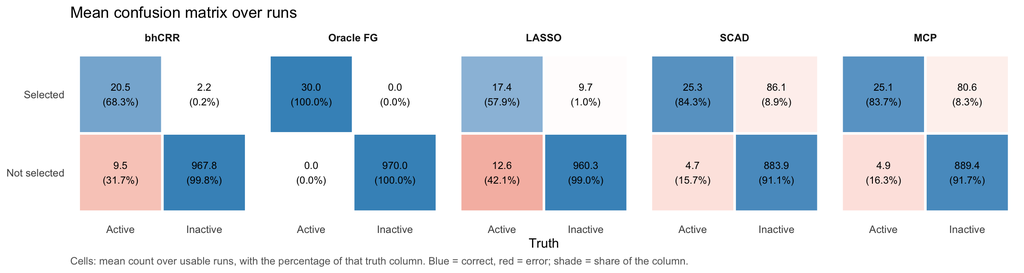

Figure 4: Mean confusion matrix per model.

```r
plot_confusion(sel)
```

```r
kbl(summarise_selection(sel))
```

Table 9: Selection and prediction metrics, mean (SD) over usable runs

| Model | Runs | True positives | False positives | False negatives | Selected | Precision | Recall (TPR) | Specificity | F1 | MCC | C-index (Wolbers) |
| --- | --- | --- | --- | --- | --- | --- | --- | --- | --- | --- | --- |
| bhCRR | 50 | 20.5 (3.3) | 2.22 (4.1) | 9.5 (3.3) | 22.7 (6.1) | 0.926 (0.11) | 0.683 (0.11) | 0.998 (0.0043) | 0.776 (0.079) | 0.785 (0.071) | 0.852 (0.024) |
| Oracle FG | 50 | 30 (0) | 0 (0) | 0 (0) | 30 (0) | 1 (0) | 1 (0) | 1 (0) | 1 (0) | 1 (0) | 0.874 (0.0085) |
| LASSO | 50 | 17.4 (3.2) | 9.72 (6.9) | 12.6 (3.2) | 27.1 (9.4) | 0.675 (0.12) | 0.579 (0.11) | 0.99 (0.0071) | 0.608 (0.06) | 0.607 (0.059) | 0.817 (0.024) |
| SCAD | 50 | 25.3 (1.9) | 86.1 (37) | 4.7 (1.9) | 111 (37) | 0.267 (0.13) | 0.843 (0.065) | 0.911 (0.038) | 0.389 (0.13) | 0.435 (0.11) | 0.935 (0.041) |
| MCP | 50 | 25.1 (1.6) | 80.6 (22) | 4.88 (1.6) | 106 (22) | 0.249 (0.058) | 0.837 (0.053) | 0.917 (0.023) | 0.38 (0.07) | 0.426 (0.064) | 0.952 (0.018) |

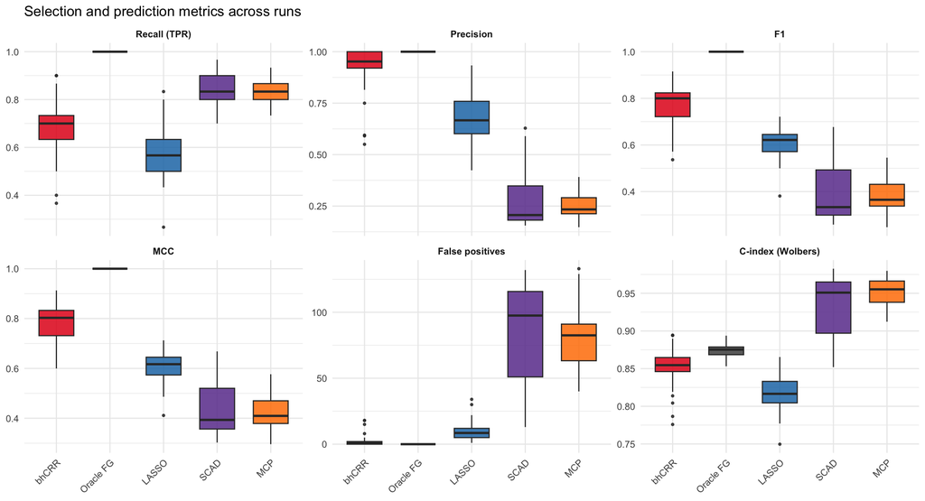

Figure 5: Distribution over runs of the selection metrics and the Wolbers C-index.

```r
plot_selection(sel)
```

## By correlation block

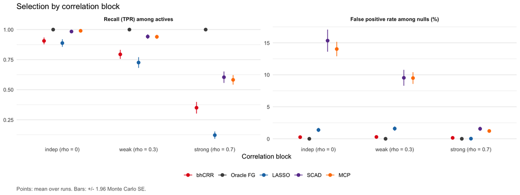

Figure 6: Recall among the active predictors and false positive rate among the null predictors, by block.

```r
sbb <- selection_by_block(res$by_block, res$performance, models)
plot_selection_by_block(sbb)
```

```r
kbl(summarise_selection_by_block(sbb), digits = 3)
```

Table 10: Selection by block. FP rate pools counts over runs.

| Block | Model | Runs | Mean TP | Mean FN | Mean FP | Recall | FP rate (%) |
| --- | --- | --- | --- | --- | --- | --- | --- |
| indep (rho = 0) | bhCRR | 50 | 9.06 | 0.94 | 0.84 | 0.906 | 0.255 |
| indep (rho = 0) | Oracle FG | 50 | 10.00 | 0.00 | 0.00 | 1.000 | 0.000 |
| indep (rho = 0) | LASSO | 50 | 8.88 | 1.12 | 4.56 | 0.888 | 1.382 |
| indep (rho = 0) | SCAD | 50 | 9.84 | 0.16 | 50.62 | 0.984 | 15.339 |
| indep (rho = 0) | MCP | 50 | 9.90 | 0.10 | 46.30 | 0.990 | 14.030 |
| weak (rho = 0.3) | bhCRR | 50 | 7.94 | 2.06 | 0.92 | 0.794 | 0.288 |
| weak (rho = 0.3) | Oracle FG | 50 | 10.00 | 0.00 | 0.00 | 1.000 | 0.000 |
| weak (rho = 0.3) | LASSO | 50 | 7.26 | 2.74 | 5.10 | 0.726 | 1.594 |
| weak (rho = 0.3) | SCAD | 50 | 9.42 | 0.58 | 30.50 | 0.942 | 9.531 |
| weak (rho = 0.3) | MCP | 50 | 9.40 | 0.60 | 30.38 | 0.940 | 9.494 |
| strong (rho = 0.7) | bhCRR | 50 | 3.50 | 6.50 | 0.46 | 0.350 | 0.144 |
| strong (rho = 0.7) | Oracle FG | 50 | 10.00 | 0.00 | 0.00 | 1.000 | 0.000 |
| strong (rho = 0.7) | LASSO | 50 | 1.22 | 8.78 | 0.06 | 0.122 | 0.019 |
| strong (rho = 0.7) | SCAD | 50 | 6.04 | 3.96 | 5.00 | 0.604 | 1.562 |
| strong (rho = 0.7) | MCP | 50 | 5.82 | 4.18 | 3.90 | 0.582 | 1.219 |

# Discussion